# 의학통계방법론 1조 4주차 과제

김재혁, 정지현

2022-03-31

```r
getwd()
```

```
## [1] "C:/git_blog/study/data/ch9"
```

```r
library(readxl)
library(dplyr)
library(kableExtra)
library(PairedData)
```

**엑셀파일불러오기**

```r
#모든 시트를 하나의 리스트로 불러오는 함수
read_excel_allsheets <- function(file, tibble = FALSE) {
  sheets <- readxl::excel_sheets(file)
  x <- lapply(sheets, function(X) readxl::read_excel(file, sheet = X))
  if(!tibble) x <- lapply(x, as.data.frame)
  names(x) <- sheets
  x
}
```

## 0.1 9장

**9장 연습문제 불러오기**

```r
#data_chap09에 연습문제 9장 모든 문제 저장
data_chap09 <- read_excel_allsheets("data_chap09.xls")

#연습문제 각각 데이터 생성
for (x in 1:length(data_chap09)){
  assign(paste0('ex9_',1:length(data_chap09))[x],data_chap09[x])
  }

#연습문제 데이터 형식을 리스트에서 데이터프레임으로 변환
for (x in 1:length(data_chap09)){
  assign(paste0('ex9_',1:length(data_chap09))[x],data.frame(data_chap09[x]))
  }
```

## 0.2 EXAMPLE 9.1

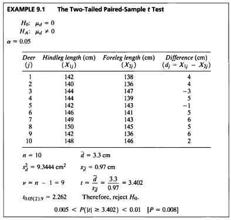

```r
#데이터셋
ex9_1%>%
  kbl(caption = "Dataset",escape=F) %>%
  kable_styling(bootstrap_options = c("striped", "hover", "condensed", "responsive"))
```

Dataset

| exam9_1.deer | exam9_1.hindleg | exam9_1.foreleg |
| --- | --- | --- |
| 1 | 142 | 138 |
| 2 | 140 | 136 |
| 3 | 144 | 147 |
| 4 | 144 | 139 |
| 5 | 142 | 143 |
| 6 | 146 | 141 |
| 7 | 149 | 143 |
| 8 | 150 | 145 |
| 9 | 142 | 136 |
| 10 | 148 | 146 |

- 해당 데이터는 사슴의 앞 다리와 뒷 다리에 대한 데이터로써 서로 짝을 이룬 대응표본 데이터이다.
- 사슴 모집단의 앞 다리 길이와 뒷 다리 길이의 차이가 있는지 검정하고자 한다.

$$\begin{aligned}
H_0 &: \mu_d = 0 \\
H_1 &: \mu_d \not=\ 0
\end{aligned}$$

- 서로 짝을 이룬 데이터이므로 Paired Sample t-test를 시행할 수 있으며, 앞 다리와 뒷 다리의 차이를 모수로 두어 One Sample t-test를 시행할 수도 있다.
- Paired Sample t-test의 경우 정규성을 만족해야하는 가정이 있으므로 정규성 검정을 시행한다.

> 표본의 크기가 작으므로 Shapiro-Wilk test를 사용할 것이다.

```r
ex9_1$diff <- ex9_1$exam9_1.hindleg-ex9_1$exam9_1.foreleg
shapiro.test(ex9_1$diff)
```

```
##
##  Shapiro-Wilk normality test
##
## data:  ex9_1$diff
## W = 0.81366, p-value = 0.02123
```

```r
t.test(ex9_1$exam9_1.hindleg,ex9_1$exam9_1.foreleg,mu=0,alt='two.sided', paired=T) # t.test(ex9_1$diff,mu=0,alt='two.sided') 같은 결과를 준다.
```

```
##
##  Paired t-test
##
## data:  ex9_1$exam9_1.hindleg and ex9_1$exam9_1.foreleg
## t = 3.4138, df = 9, p-value = 0.007703
## alternative hypothesis: true mean difference is not equal to 0
## 95 percent confidence interval:
##  1.113248 5.486752
## sample estimates:
## mean difference
##             3.3
```

- 검정통계량 값이 3.4138 문제의 값인 3.402와 다르게 나온 이유는 두 표본에 대한 표준편차가 반올림을 해서 계산이 되었기 때문이다.
- 이 예제에서는 두 표본에 대한 표준편차 0.9666667를 소수점 셋째자리에서 반올림하였다.
- p-value = 0.007703이므로 유의수준 5%하에 귀무가설을 기각할 수 있다.
- 즉, 사슴 모집단의 앞 다리와 뒷 다리의 길이의 차이가 있다고 할 수 있다.

## 0.3 EXAMPLE 9.2

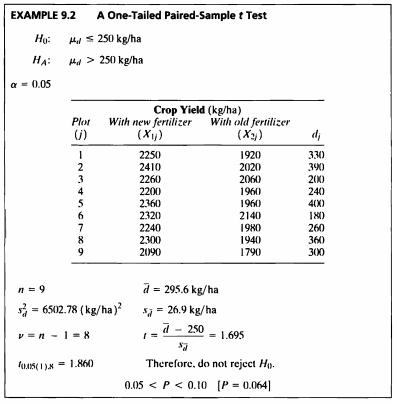

```r
#데이터셋
ex9_2%>%
  kbl(caption = "Dataset",escape=F) %>%
  kable_styling(bootstrap_options = c("striped", "hover", "condensed", "responsive"))
```

Dataset

| exam9_2.plot | exam9_2.new | exam9_2.old | exam9_2.d |
| --- | --- | --- | --- |
| 1 | 2250 | 1920 | 330 |
| 2 | 2410 | 2020 | 390 |
| 3 | 2260 | 2060 | 200 |
| 4 | 2200 | 1960 | 240 |
| 5 | 2360 | 1960 | 400 |
| 6 | 2320 | 2140 | 180 |
| 7 | 2240 | 1980 | 260 |
| 8 | 2300 | 1940 | 360 |
| 9 | 2090 | 1790 | 300 |

- 해당 데이터는 기존 비료와 새로운 비료에 따른 수확량을 기록한 데이터이다.
- 새로운 비료와 기존 비료의 곡물 수확량 차이 모평균에 대한 검정을 수행할 것이다.

- Paired Sample t-test의 경우 정규성을 만족해야하는 가정이 있으므로 정규성 검정을 시행한다.

> 표본의 크기가 작으므로 Shapiro-Wilk test를 사용할 것이다.

```r
shapiro.test(ex9_2$exam9_2.d)
```

```
##
##  Shapiro-Wilk normality test
##
## data:  ex9_2$exam9_2.d
## W = 0.94359, p-value = 0.6202
```

```r
t.test(ex9_2$exam9_2.new, ex9_2$exam9_2.old, mu=250, alt='greater', paired=T) # t.test(ex9_2$exam9_2.d, mu=250, alt="greater")  같은 결과를 준다.
```

```
##
##  Paired t-test
##
## data:  ex9_2$exam9_2.new and ex9_2$exam9_2.old
## t = 1.6948, df = 8, p-value = 0.06428
## alternative hypothesis: true mean difference is greater than 250
## 95 percent confidence interval:
##  245.571     Inf
## sample estimates:
## mean difference
##        295.5556
```

## 0.4 EXAMPLE 9.3

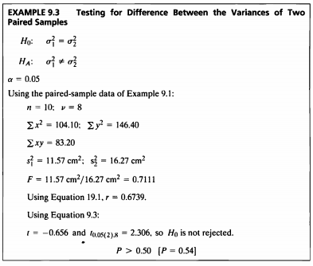

- 이 예제는 Example 9.1 데이터를 사용하여 모분산이 같은지에 대한 검정을 해보도록 할 것이다.

$$\begin{aligned}
H_0 &: \sigma_1^2=\sigma_2^2 \\
H_1 &: \sigma_1^2\neq\sigma_2^2
\end{aligned}$$

- 두개의 paired-samples에 대해 분산이 같은지 여부를 검증하기 위해 Pitman 검정을 진행했다.

> 직접 함수를 작성해서 구하여 보자.

```r
v1=round(var(ex9_1$exam9_1.hindleg),2)
v2=round(var(ex9_1$exam9_1.foreleg),2)
r=cor(ex9_1$exam9_1.hindleg,ex9_1$exam9_1.foreleg)
F=round(v1/v2,4)
n=length(ex9_1$exam9_1.hindleg)
t=round(((F-1)*sqrt(n-2))/(2*sqrt(F*(1-r^2))),3)
t_0.05=round(qt(0.025, df=8, lower.tail=F),3)
cat("\t F=",F," t=",t," t_0.05=",t_0.05, "\n\t Therefore cannot reject null hypothesis")
```

```
##   F= 0.7111  t= -0.656  t_0.05= 2.306
##   Therefore cannot reject null hypothesis
```

- t 값은 -0.656으로 자유도가 8인 t_0.05값 2.306보다 그 절대값이 작기 때문에 사슴 앞 다리의 길이와 사슴 뒷 다리의 길이의 모분산이 같다는 귀무가설을 기각할 수 없다.

> 다음은 PairedData 패키지의 pitman.morgan.test.default() 함수 사용

```r
library(PairedData)
pitman.morgan.test.default(ex9_1$exam9_1.hindleg,ex9_1$exam9_1.foreleg)
```

```
##
##  Paired Pitman-Morgan test
##
## data:  ex9_1$exam9_1.hindleg and ex9_1$exam9_1.foreleg
## t = -0.65591, df = 8, p-value = 0.5303
## alternative hypothesis: true ratio of variances is not equal to 1
## 95 percent confidence interval:
##  0.227042 2.226964
## sample estimates:
## variance of x variance of y
##      11.56667      16.26667
```

- p-value가 0.5303으로 유의수준 5%하에 귀무가설을 기각할 수 없다.

> Fisher의 방법으로 분산이 동일한지 검정

```r
var.test(ex9_1$exam9_1.hindleg,ex9_1$exam9_1.foreleg,ratio=1,alternative = "two.sided",paired=T)
```

```
##
##  F test to compare two variances
##
## data:  ex9_1$exam9_1.hindleg and ex9_1$exam9_1.foreleg
## F = 0.71107, num df = 9, denom df = 9, p-value = 0.6197
## alternative hypothesis: true ratio of variances is not equal to 1
## 95 percent confidence interval:
##  0.1766186 2.8627458
## sample estimates:
## ratio of variances
##          0.7110656
```

- p-value가 0.6197로 유의수준 5%하에 귀무가설을 기각할 수 없다.
- 따라서 유의수준 5%하에 사슴 앞 다리 길이와 뒷 다리 길이의 모분산이 다르다고 말할만한 충분한 근거가 없다.

## 0.5 EXAMPLE 9.4

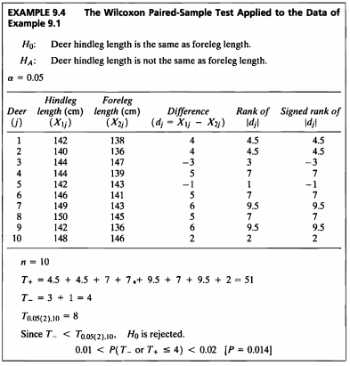

- 이 예제에서는 Example 9.1 데이터가 정규성 가정을 만족하지 못하였으므로 비모수 검정을 시행하여보겠다.

$$H_o:\ Deer\ hindleg\ length\ is\ the\ same\ as\ foreleg\ length.\\
H_A: eer\ hind\ leg\ length\ is\ not\ the\ same\ as\ forele\ length.$$

```r
ex9_1$diff=ex9_1$exam9_1.hindleg-ex9_1$exam9_1.foreleg
ex9_1$d.rank= rank(abs(ex9_1$diff))
ex9_1$sign_rank= ifelse(ex9_1$diff < 0, ex9_1$d.rank *(-1), ex9_1$d.rank)
T.plus= sum(subset(ex9_1, sign_rank>=0)$sign_rank)
T.minus= abs(sum(subset(ex9_1, sign_rank< 0)$sign_rank))
```

```r
T.plus;T.minus
```

```
## [1] 51
```

```
## [1] 4
```

- signed rank의 양수 합은 51, 음수 합은 4이다.
- 대응 표본에 대하여 비모수 검정법인 Wilcoxon signed rank test 수행하였다.

```r
wilcox.test(ex9_1$exam9_1.hindleg, ex9_1$exam9_1.foreleg, paired=T)
```

```
##
##  Wilcoxon signed rank test with continuity correction
##
## data:  ex9_1$exam9_1.hindleg and ex9_1$exam9_1.foreleg
## V = 51, p-value = 0.01859
## alternative hypothesis: true location shift is not equal to 0
```

- p유의수준 5%에서 기각역은 8이다.
- 4 < 8이므로 귀무가설을 기각하고 대립가설을 채택한다.
- 즉. 유의수준 5% 하에서 사슴 앞다리 길이의 모평균과 뒷다리 길이의 모평균은 다르다고 볼 수 있는 충분한 근거가 있다.